# Väestön ja asuntotarpeen ennustemalli KASSU

Arto Viinikka ja Anna Strandell, Syke

21.6.2023

### Taustaa

KASSU-työkalu on kehitetty kuntien asumisen suunnittelun tueksi. Työkalu koostuu väestöennuste- ja asuntokantaennustemallista, ja on tulosta Suomen ympäristökeskuksen (Syke) ja Asumisen rahoitus- ja kehittämiskeskuksen (ARA) yhteishankkeesta. Työkalu on tehty Sykessä. Tarkemmat funktioiden kuvaukset löytyvät R-skripteistä. Lisätietoa työkalusta löytyy: https://helda.helsinki.fi/handle/10138/358430

### Väestöennuste

Väestöennuste on mallinnettu aluekohtaisesti 1-vuotisikäryhmille, sukupuolittain, kohorttikomponentti-menetelmällä, joka vanhentaa väestöä vuosittain huomioiden eri komponenttien vaikutuksen. Mallin komponentteina toimivat kuntien välinen ja sisäinen muuttoliike, maahanmuutto, kuolleisuus ja syntyvyys. Mallinnuksen pienin alueellinen yksikkö on 250 m x 250 m ruudukko, joten malli mahdollistaa ennusteen kaikille tätä suuremmille aluejaoille (esim. yhdyskuntarakenteen vyöhykejako tai tilastoaluejako). Ennustekausi on tällä hetkellä vuoteen 2040 asti. Laskenta tapahtuu matriisipohjaisesti eli kaikki lähtoaineistot luetaan malliin taulukkomuodossa.

#### Lähtöaineistot

Malli käyttää Lähtöaineistoina Rakennus- ja huoneistorekisteriä (RHR) sekä Tilastokeskuksen (TK) tarkempaa ruutukohtaista muuttoliikeaineistoa. Näiden lisäksi hyödynnetään seuraavia avoimia tilastokeskuksen rajapinta-aineistoja: kunnittaiset hedelmällisyyskertoimet ikäluokittain, kuolleisuuskertoimet iän ja sukupuolen mukaan kunnittain sekä maahan- ja maastamuuton kunnittaisia tilastoja iän ja sukupuolen mukaan. Mallissa hyödynnetyt aineistot on merkitty taulukkoon 1.

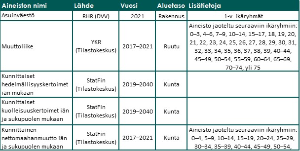

Taulukko 1.Väestöennusteessa hyödynnetyt lähtöaineistot

#### Trendiennusteen luominen Oulun yhdyskuntarakenteen vyöhykkeille

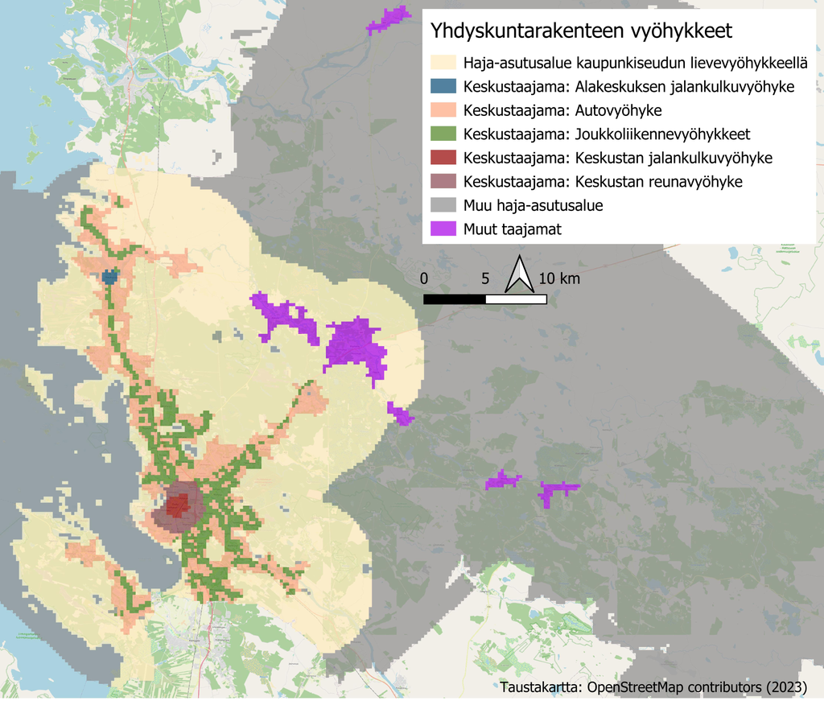

Kuva 1.Oulun yhdyskuntarakenteen vyöhykkeet

#### Ennusteparametrien asettaminen

Asetetaan tarvittavat parametrit ennustemallille.

```r
## Set required parameters ##
##-------------------------##

## database connections ##
server = "server_name"

## Building and dwelling register
rhr = building_and_dwelling_register_source

## Migration data
migration = migration_data_source

## Study area
area = study_area_source

## Number of sub-regions inside the study area (e.g., number of urban zones)
col = 8

## Count of the age groups. Do not change!
n_ages = 101

## Starting year of the prediction
start_year = 2021

## Years to be predicted
n_estimation_years = 20

## The years on which the trend prediction is based
## Trend prediction uses mean values from these years to create required variables for population prediction
pred_years = c(2017, 2018, 2019, 2020, 2021)

## Municipality name
mun_name = "Oulu"

## Municipality number
mun_nro = '564'
```

#### Vaihtoehtoisen skenaarion muodostaminen

Käyttäjä voi muokata ennusteen parametreja ja luoda vaihtoehtoisia skenaarioita trendiennusteen tueksi. Tarkempi kuvaus parametrien muokkauksesta löytyy R-koodeista.

#### Lähtöaineistojen haku

##### Olemassa olevan väestö

Poimitaan Oulun yhdyskuntarakenteen vyöhykkeiden olemassa oleva väestömäärä 1-vuotis ikäryhmittäin. Malli lukee esimerkin tiedot MSsql-tietokannasta hyödyntäen rakennus-ja huoneistorekisterin väestötietoja.

```r
## Load source function ##
##----------------------##
source("fun_existing_population.R") ##  Function returns existing population from the study area
```

Esimerkki naisten lähtöväestöstä Oulun yhdyskuntarakenteen vyöhykkeillä (lkm ikävuosittain). Esimerkissä vain ensimmäiset 10 ikävuotta

|  | Alue 1 | Alue 2 | Alue 3 | Alue 4 | Alue 5 | Alue 6 | Alue 7 | Alue 8 |
| --- | --- | --- | --- | --- | --- | --- | --- | --- |
| 1 | 44 | 78 | 8 | 542 | 352 | 59 | 13 | 24 |
| 2 | 30 | 68 | 7 | 486 | 313 | 63 | 15 | 22 |
| 3 | 37 | 61 | 6 | 432 | 320 | 56 | 23 | 21 |
| 4 | 26 | 57 | 7 | 441 | 311 | 64 | 15 | 29 |
| 5 | 24 | 52 | 12 | 414 | 339 | 81 | 13 | 27 |
| 6 | 25 | 53 | 11 | 517 | 394 | 84 | 22 | 29 |
| 7 | 25 | 47 | 7 | 477 | 424 | 72 | 18 | 28 |
| 8 | 36 | 51 | 11 | 497 | 397 | 84 | 29 | 41 |
| 9 | 21 | 62 | 15 | 499 | 429 | 82 | 14 | 37 |
| 10 | 39 | 65 | 15 | 539 | 490 | 84 | 31 | 33 |

##### Muuttoliike

Muuttoliike johdetaan Tilastokeskuksen ruutupohjaisesta muuttoliikeaineistosta, josta lasketaan viimeisen viiden vuoden keskiarvo.

```r
## Load source functions ##
##-----------------------##
source("fun_in_migration_female.R") # function returns the amount of female migration in to the study area
source("fun_out_migration_female.R") # function returns the amount of female migration from the study area
source("fun_in_migration_male.R") # function returns the amount of male migration in to the study area
source("fun_out_migration_male.R") # function returns the amount of male migration from the study area
```

Esimerkki naisten vuotuisesta tulomuutosta Oulun yhdyskuntarakenteen vyöhykkeillä (lkm, ikäryhmittäin). Esimerkissä vain ensimmäiset 10 ikävuotta

|  | Alue 1 | Alue 2 | Alue 3 | Alue 4 | Alue 5 | Alue 6 | Alue 7 | Alue 8 |
| --- | --- | --- | --- | --- | --- | --- | --- | --- |
| 1 | 15 | 19 | 3 | 128 | 78 | 12 | 2 | 3 |
| 2 | 15 | 19 | 3 | 128 | 78 | 12 | 2 | 3 |
| 3 | 15 | 19 | 3 | 128 | 78 | 12 | 2 | 3 |
| 4 | 15 | 19 | 3 | 128 | 78 | 12 | 2 | 3 |
| 5 | 11 | 17 | 4 | 104 | 66 | 12 | 1 | 3 |
| 6 | 11 | 17 | 4 | 104 | 66 | 12 | 1 | 3 |
| 7 | 11 | 17 | 4 | 104 | 66 | 12 | 1 | 3 |
| 8 | 10 | 11 | 4 | 80 | 57 | 9 | 1 | 2 |
| 9 | 10 | 11 | 4 | 80 | 57 | 9 | 1 | 2 |
| 10 | 10 | 11 | 4 | 80 | 57 | 9 | 1 | 2 |

##### Maahanmuutto

Maahanmuutto johdetaan kuntakohtaisesta nettomaahanmuutosta Tilastokeskuksen rajapinnasta, josta lasketaan keskiarvo edelliseltä viideltä vuodelta. Koska nettomaahanmuutto on kunnittaista tietoa, jaetaan sen vaikutus osa-alueille suhteessa väestömäärään. Tällöin suurin muuttoliike kohdistuu alueelle, missä on eniten väestöä.

```r
## Load source functions ##
##-----------------------##
source("fun_immigration_female.R") # function returns the amount of female net immigration
source("fun_immigration_male.R") # function returns the amount of male net immigration
```

Esimerkki naisten vuotuisesta maahanmuutosta Oulun yhdyskuntarakenteen vyöhykkeillä (lkm, ikäryhmittäin). Esimerkissä vain ensimmäiset 10 ikävuotta

|  | Alue 1 | Alue 2 | Alue 3 | Alue 4 | Alue 5 | Alue 6 | Alue 7 | Alue 8 |
| --- | --- | --- | --- | --- | --- | --- | --- | --- |
| 1 | 0.27 | 0.49 | 0.05 | 3.39 | 2.20 | 0.37 | 0.08 | 0.15 |
| 2 | 0.19 | 0.42 | 0.04 | 3.04 | 1.96 | 0.39 | 0.09 | 0.14 |
| 3 | 0.23 | 0.38 | 0.04 | 2.70 | 2.00 | 0.35 | 0.14 | 0.13 |
| 4 | 0.16 | 0.36 | 0.04 | 2.76 | 1.94 | 0.40 | 0.09 | 0.18 |
| 5 | 0.15 | 0.32 | 0.07 | 2.59 | 2.12 | 0.51 | 0.08 | 0.17 |
| 6 | 0.09 | 0.20 | 0.04 | 1.95 | 1.49 | 0.32 | 0.08 | 0.11 |
| 7 | 0.09 | 0.18 | 0.03 | 1.80 | 1.60 | 0.27 | 0.07 | 0.11 |
| 8 | 0.14 | 0.19 | 0.04 | 1.87 | 1.50 | 0.32 | 0.11 | 0.15 |
| 9 | 0.08 | 0.23 | 0.06 | 1.88 | 1.62 | 0.31 | 0.05 | 0.14 |
| 10 | 0.15 | 0.25 | 0.06 | 2.03 | 1.85 | 0.32 | 0.12 | 0.12 |

##### Kuolleisuus

Kuolleisuus johdetaan kuntakohtaisista naisten ja miesten kuolleisuuskertoimista. Alueen olemassa oleva väestömäärä kuntien välisen muuttoliikkeen ja maahanmuuton jälkeen kerrotaan kuolleisuuskertoimilla, jolloin saadaan poistuva väestönosa. Tämä vähennetään olemassa olevasta väestöstä, jolloin saadaan selville väestömäärä kuolleisuuden jälkeen. Kunnan osa-alueilla käytetään koko kunnan kuolleisuuskertoimia.

```r
## Load source function ##
##----------------------##
source("fun_mortality.R") # function returns the amount of male and female mortality rates
```

Esimerkki naisten kuolleisuuskertoimista ikävuosittain Oulun yhdyskuntarakenteen vyöhykkeillä. Esimerkissä vain ensimmäiset 10 ikävuotta. Kuolleisuuskertoimet on käännetty, jolloin saadaan selville jäljelle jäävä väestönosa

|  | Alue 1 | Alue 2 | Alue 3 | Alue 4 | Alue 5 | Alue 6 | Alue 7 | Alue 8 |
| --- | --- | --- | --- | --- | --- | --- | --- | --- |
| 1 | 0.9998 | 0.9998 | 0.9998 | 0.9998 | 0.9998 | 0.9998 | 0.9998 | 0.9998 |
| 2 | 0.9999 | 0.9999 | 0.9999 | 0.9999 | 0.9999 | 0.9999 | 0.9999 | 0.9999 |
| 3 | 0.9999 | 0.9999 | 0.9999 | 0.9999 | 0.9999 | 0.9999 | 0.9999 | 0.9999 |
| 4 | 0.9999 | 0.9999 | 0.9999 | 0.9999 | 0.9999 | 0.9999 | 0.9999 | 0.9999 |
| 5 | 0.9999 | 0.9999 | 0.9999 | 0.9999 | 0.9999 | 0.9999 | 0.9999 | 0.9999 |
| 6 | 1.0000 | 1.0000 | 1.0000 | 1.0000 | 1.0000 | 1.0000 | 1.0000 | 1.0000 |
| 7 | 0.9999 | 0.9999 | 0.9999 | 0.9999 | 0.9999 | 0.9999 | 0.9999 | 0.9999 |
| 8 | 1.0000 | 1.0000 | 1.0000 | 1.0000 | 1.0000 | 1.0000 | 1.0000 | 1.0000 |
| 9 | 1.0000 | 1.0000 | 1.0000 | 1.0000 | 1.0000 | 1.0000 | 1.0000 | 1.0000 |
| 10 | 1.0000 | 1.0000 | 1.0000 | 1.0000 | 1.0000 | 1.0000 | 1.0000 | 1.0000 |

##### Syntyvyys

Syntyvyys johdetaan kuntakohtaisista hedelmällisyyskertoimista, imeväiskuolleisuudesta, sekä tyttöjen ja poikien osuudesta syntyvistä. Kuntien välisen muuttoliikkeen, maahanmuuton ja kuolleisuuden jälkeen alueen 14-50 -vuotiaiden naisten väestömäärä kerrotaan hedelmällisyyskertoimilla ja tyttöjen ja poikien osuudella syntyvistä. Tästä vähennetään imeväiskuolleisuus, jolloin saadaan kyseisenä vuonna syntyvien tyttöjen ja poikien osuus, jotka lisätään väestöön. Kunnan osa-alueilla käytetään koko kunnan hedelmällisyyskertoimia.

```r
## Load source function ##
##----------------------##
source("fun_birth.R") # function returns the amount of male and female birth rates
```

Esimerkki naisten hedelmällisyyskertoimista Oulun yhdyskuntarakenteen vyöhykkeillä (prosenttia, ikäryhmittäin). Esimerkissä vain ensimmäiset 10 ikävuotta

|  | Alue 1 | Alue 2 | Alue 3 | Alue 4 | Alue 5 | Alue 6 | Alue 7 | Alue 8 |
| --- | --- | --- | --- | --- | --- | --- | --- | --- |
| 1 | 0.0000 | 0.0000 | 0.0000 | 0.0000 | 0.0000 | 0.0000 | 0.0000 | 0.0000 |
| 2 | 0.0002 | 0.0002 | 0.0002 | 0.0002 | 0.0002 | 0.0002 | 0.0002 | 0.0002 |
| 3 | 0.0007 | 0.0007 | 0.0007 | 0.0007 | 0.0007 | 0.0007 | 0.0007 | 0.0007 |
| 4 | 0.0017 | 0.0017 | 0.0017 | 0.0017 | 0.0017 | 0.0017 | 0.0017 | 0.0017 |
| 5 | 0.0036 | 0.0036 | 0.0036 | 0.0037 | 0.0037 | 0.0037 | 0.0037 | 0.0037 |
| 6 | 0.0074 | 0.0074 | 0.0074 | 0.0074 | 0.0074 | 0.0074 | 0.0074 | 0.0074 |
| 7 | 0.0124 | 0.0124 | 0.0124 | 0.0124 | 0.0124 | 0.0124 | 0.0124 | 0.0124 |
| 8 | 0.0169 | 0.0169 | 0.0169 | 0.0169 | 0.0169 | 0.0169 | 0.0169 | 0.0169 |
| 9 | 0.0211 | 0.0211 | 0.0211 | 0.0211 | 0.0211 | 0.0211 | 0.0211 | 0.0211 |
| 10 | 0.0245 | 0.0245 | 0.0245 | 0.0245 | 0.0245 | 0.0245 | 0.0245 | 0.0245 |

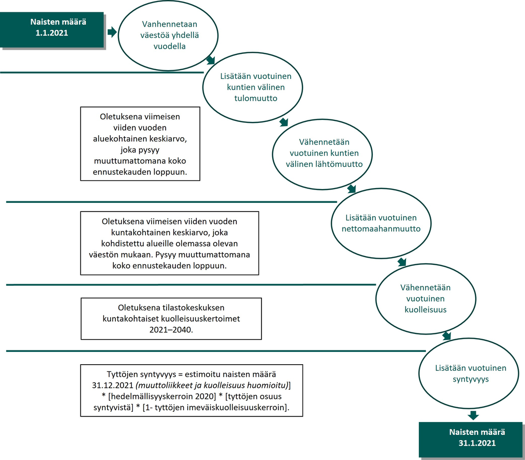

Kuva 2.Väestöennusteen laskentaperiaate

#### Väestöennustemallin ajaminen

Malli käyttää yhtä pääfunktiota, joka jakautuu useampaan alifunktioon. Tarkempi kuvaus mllin laskennasta löytyy R-skripteistä.

```r
## Run the model   ##
##-----------------##
source("fun_population_prediction.R")
pop_pred = fun_population_prediction(area, mun_nro, mun_name, rhr, mod_inmig_rate,
                                         mod_outmig_rate, mod_fert_rate,mod_mort_rate,vaesto_naiset,vaesto_miehet,col)
```

### Tulosesimerkkejä

Tulosaineistona syntyy useita erilaisia kuvaajia, visualisointeja ja raakadataa taulukkomuodossa.

#### Väestöennusteen kuvaaja

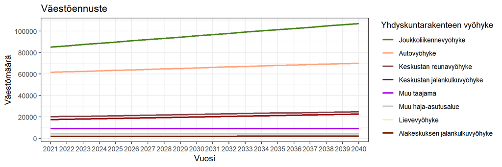

Kuva 3. Oulun väestöennuste yhdyskuntarakenteen vyöhykkeillä vuoteen 2040 asti

#### Väestöpyramidi

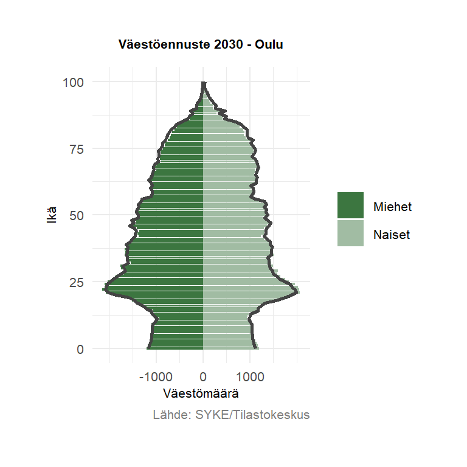

Kuva 4. KASSU-mallin tuottama väestöpyramidi verrattuna Tilastokeskuksen väestöpyramidiin (harmaa viiva)

#### Väestönmuutos kartalla alueittain

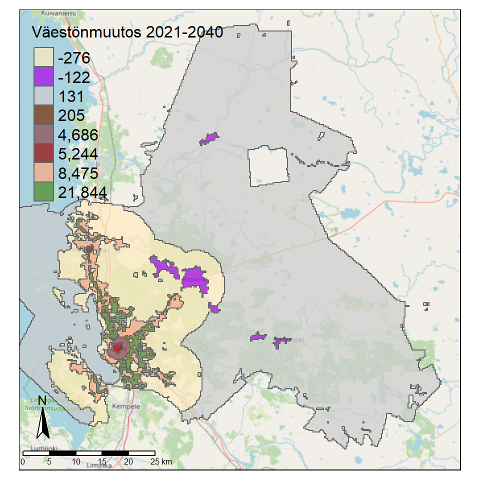

### Asuntotarve-ennuste

Asuntotarve-ennuste johdetaan muodostetun väestöennusteen pohjalta niin, että naisia ja miehiä käsitellään laskennassa tästä eteenpäin yhdessä. Ennuste voidaan tuottaa tällä hetkellä vuoteen 2040 asti. Mallin tuottama asuntokantaennuste käyttää lähtöaineistoina lisäksi ja rakennus- ja huoneistorekisteriä (RHR), jonka pohjalta se muodostaa ennusteeseen tarvittavat lähtömuuttujat (taulukko 2). Ennuste voidaan tuottaa tällä hetkellä vuoteen 2040 asti.

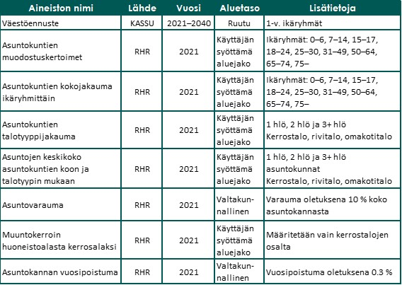

Taulukko 2.Asuntotarve-ennusteen lähtöaineistot

Malli luokittelee tuotetun väestöennusteen aluksi yhdeksään ikäryhmään. Väestön muuntaminen asuntokunniksi tapahtuu kertomalla väestöennuste asuntokuntien muodostuskertoimien perusteella. Tämän jälkeen asuntokunnat jaetaan kolmeen luokkaan (1 hlö, 2 hlö ja 3+ hlö) lähtövuoden asuntokuntien kokojakauman perusteella. Nykyjakauma toimii oletusarvona koko ennustekaudelle. Näin saadaan asuntokuntien kokonaismäärät ikäryhmittäin eri asuntokuntien kokoluokissa (1 hlö, 2 hlö ja 3+ henkilön asuntokunnat).

Asuntokunnat summataan yhteen asuntokuntien koon mukaan, jolloin saadaan selville asuntokuntien kokonaismäärä. Kokonaismäärä jaetaan eri talotyyppeihin (kerrostalo, rivitalo, omakotitalo) lähtövuoden talotyyppijakauman perusteella. Muodostunut asuntokuntien määrä talotyypeittäin muutetaan asunnoiksi lähtövuoden asuntojen keskikokojakauman mukaan, jolloin saadaan lopullinen, ennusteen mukainen asuntojen määrä. Kokojakaumaa käytetään oletuksena koko ennustekauden loppuun.

Tämän jälkeen huomioidaan asuntovarauma eli vailla vakituisia asukkaita olevat asunnot. Varauman suuruudeksi on oletusarvona asetettu 10 % koko asuntokannasta, mikä on valtakunnallinen RHR:stä laskettu keskiarvo. Tämän jälkeen huomioidaan vielä asuntokannan vuosipoistuma, joka on oletuksena 0,3 % asunto-kannasta. Vertaamalla väestöennusteen perusteella tuotettua asuntojen määrää olemassa olevaan, lähtövuoden asuntojen määrään (RHR), voidaan tehdä aluekohtainen arvio tuotanto- tai vähennystarpeesta talotyypeittäin. Jos olemassa oleva kanta on suurempi kuin ennustettu asuntomäärä esitetään vähennystarvetta, ja päinvastaisessa tilanteessa taas tuotantotarvetta.

#### Lähtöaineistojen haku

##### Aluekohtainen väestöennuste

```r
## Load population prediction ##
##----------------------------##
population_prediction = pop_pred$`n ikavuosittain alue`+ pop_pred$`m ikavuosittain alue`
```

##### Asuntokuntien kokojakauma

```r
## Load source function ##
##-----------------------##
source("fun_familysize.R") # Function returns size of household-dwelling unit ##
```

Esimerkki asuntokuntien kokojakaumasta keskustan jalankulkuvyöhykkeellä Oulussa perhekoon mukaan ikäryhmittäin.

|  | 1 hlo | 2 hlo | 3+ hlo |
| --- | --- | --- | --- |
| 1_7v | 0.0054 | 0.1897 | 0.8049 |
| 8_13v | 0.0000 | 0.2226 | 0.7774 |
| 14_17v | 0.0339 | 0.2839 | 0.6822 |
| 18_25v | 0.6578 | 0.2748 | 0.0675 |
| 26_31v | 0.5888 | 0.3533 | 0.0578 |
| 32_49v | 0.5683 | 0.2595 | 0.1722 |
| 51_65v | 0.6098 | 0.3220 | 0.0682 |
| 66_74v | 0.5757 | 0.4056 | 0.0187 |
| 75_101v | 0.7042 | 0.2879 | 0.0078 |

##### Asuntokuntien muodostumiskertoimet

```r
## Load source function ##
##----------------------##
source("fun_household_rates.R") ##  Function returns household rates in different age groups
```

Esimerkki asuntokuntien muodostumiskertoimesta keskustan jalankulkuvyöhykkeellä Oulussa ikäryhmittäin.

|  | Kerroin |
| --- | --- |
| 1_7v | 0.3122 |
| 8_13v | 0.2949 |
| 14_17v | 0.4632 |
| 18_25v | 0.7650 |
| 26_31v | 0.7366 |
| 32_49v | 0.6901 |
| 51_65v | 0.7262 |
| 66_74v | 0.7320 |
| 75_101v | 0.7880 |

##### Asuntokuntien jakautuminen talotyypeittäin

```r
## Load source function ##
##----------------------##
source("fun_household_housetype_distribution.R") ## Function returns percentage of different households and house types
```

Esimerkki asuntokuntien jakautumisesta talotyypeittäin keskustan jalankulkuvyöhykkeellä Oulussa.

|  | Omakotitalo | Rivitalo | Kerrostalo |
| --- | --- | --- | --- |
| 1 hlö | 0.0024 | 0.0024 | 0.9952 |
| 2 hlö | 0.0072 | 0.0054 | 0.9875 |
| 3+ hlö | 0.0383 | 0.0298 | 0.9319 |

##### Asuntokuntien keskimääräinen pinta-ala talotyypeittäin

```r
## Load source function ##
##----------------------##
source("fun_household_meansize.R") ## Function returns mean size of different households (m2)
```

Esimerkki asuntokuntien keskimääräisestä pinta-alasta talotyypeittäin keskustan jalankulkuvyöhykkeellä Oulussa.

|  | Omakotitalo | Rivitalo | Kerrostalo |
| --- | --- | --- | --- |
| 1 hlö | 94.0500 | 59.2500 | 46.5974 |
| 2 hlö | 110.7143 | 93.2381 | 67.7772 |
| 3+ hlö | 139.9259 | 100.5714 | 78.4855 |